# RD modelling - simulations

Doranne Thomassen

3/22/2021

# Single trial

##Continuous x2

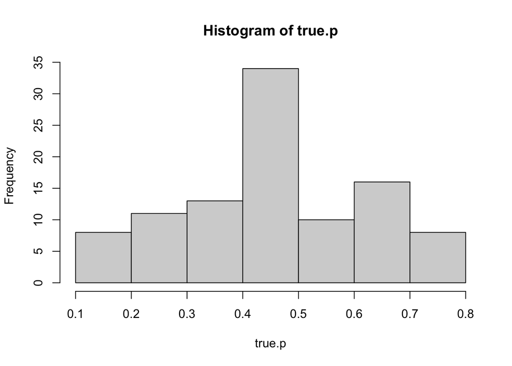

```r
set.seed(42)
n_arm <- 50
treat <- c(rep(0,n_arm), rep(1,n_arm))
cat("", file = "modelstats_cont.html", append = FALSE)

#beta1=0.3, b2=0.2, increase alpha
#alpha = 0.3
x <- runif(n=2*n_arm, min = -1, max=1)
true.beta <- 0.3
true.p <- 0.3+true.beta*treat+0.2*x
hist(true.p)
```

```r
xpred <- x
TEfun <- function(x){
  return(true.beta)
}

cure <- rbinom(n=length(treat), size=1, prob = true.p)
trial.dat <- data.frame(cure, treat, x)


plots <- run.sim(true.beta=true.beta,
        trial.dat = trial.dat,
        filename="2x_cont_p=0.3+0.3x+0.2x",
        title=expression(paste(x[i*1], " binary, ", x[i*2], "~U[-1,1], ", p[i],"=0.3+0.3",x[i*1],"+0.2",x[i*2],".")),
        true.p = true.p,
        true.TE.fun=TEfun,
        xpred = xpred,
        beta_xlim = c(0,0.6),
        beta_ylim = c(0,20))
```

```
## module glm loaded
```

[output not shown]

[output cut: 1203 more lines]

```
## pred.effect[94]   2000
## pred.effect[95]   2000
## pred.effect[96]   2000
## pred.effect[97]   2000
## pred.effect[98]   2000
## pred.effect[99]   2000
## pred.effect[100]  2000
## deviance          2000
##
## For each parameter, n.eff is a crude measure of effective sample size,
## and Rhat is the potential scale reduction factor (at convergence, Rhat=1).
##
## DIC info (using the rule, pD = var(deviance)/2)
## pD = 2.5 and DIC = 129.4
## DIC is an estimate of expected predictive error (lower deviance is better).
```

```r
beta.plot <- plots$beta.frame
plots$kable_modstats
```

1. Proposed model
3. Logistic model + transform
2. Model by Warn et al.

MLE binomial GLM id-link

MLE binomial GLM logit-link

OLS estimate

Brier.mean

0.2190

0.2205

0.2194

0.2201

0.2204

0.2188

Brier.median

0.2186

0.2205

0.2193

0.2201

0.2204

0.2188

RMSE.p.mean

0.0755

0.0839

0.0733

0.0826

0.0833

0.0826

RMSE.p.median

0.0756

0.0846

0.0739

0.0826

0.0833

0.0826

MAE.p.mean

0.0618

0.0707

0.0602

0.0701

0.0700

0.0681

MAE.p.median

0.0619

0.0713

0.0617

0.0701

0.0700

0.0681

IC

129.7560

131.7592

129.4135

130.1158

131.4415

NA

Rhat_Conv

1.0036

1.0010

1.0007

-1.0000

-1.0000

-1.0000

RunTimes

4.7978

3.4663

3.1229

0.0053

0.0015

0.0010

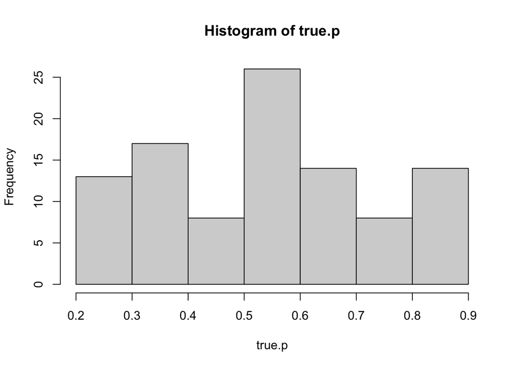

```r
rm(cure, trial.dat, true.beta, true.p, x, xpred)

#alpha = 0.4
x <- runif(n=2*n_arm, min = -1, max=1)
true.beta <- 0.3
true.p <- 0.4+true.beta*treat+0.2*x
hist(true.p)
```

```r
xpred <- x
TEfun <- function(x){
  return(true.beta)
}

cure <- rbinom(n=length(treat), size=1, prob = true.p)
trial.dat <- data.frame(cure, treat, x)


plots <- run.sim(true.beta=true.beta,
        trial.dat = trial.dat,
        filename="2x_cont_p=0.4+0.3x+0.2x",
        title=expression(paste(x[i*1], " binary, ", x[i*2], "~U[-1,1], ", p[i],"=0.4+0.3",x[i*1],"+0.2",x[i*2],".")),
        true.p = true.p,
        true.TE.fun=TEfun,
        xpred = xpred,
        beta_xlim = c(0,0.6),
        beta_ylim = c(0,20))
```

[output not shown]

[output cut: 1203 more lines]

```
## pred.effect[94]    830
## pred.effect[95]    830
## pred.effect[96]    830
## pred.effect[97]    830
## pred.effect[98]    830
## pred.effect[99]    830
## pred.effect[100]   830
## deviance          2000
##
## For each parameter, n.eff is a crude measure of effective sample size,
## and Rhat is the potential scale reduction factor (at convergence, Rhat=1).
##
## DIC info (using the rule, pD = var(deviance)/2)
## pD = 2.7 and DIC = 137.9
## DIC is an estimate of expected predictive error (lower deviance is better).
```

```r
beta.plot <- rbind(beta.plot, plots$beta.frame)
plots$kable_modstats
```

1. Proposed model
3. Logistic model + transform
2. Model by Warn et al.

MLE binomial GLM id-link

MLE binomial GLM logit-link

OLS estimate

Brier.mean

0.2348

0.2349

0.2348

0.2347

0.2348

0.2347

Brier.median

0.2349

0.2348

0.2347

0.2347

0.2348

0.2347

RMSE.p.mean

0.0952

0.0919

0.0978

0.0904

0.0920

0.0920

RMSE.p.median

0.0936

0.0905

0.0967

0.0904

0.0920

0.0920

MAE.p.mean

0.0777

0.0755

0.0798

0.0738

0.0756

0.0751

MAE.p.median

0.0762

0.0742

0.0787

0.0738

0.0756

0.0751

IC

137.8617

138.6779

137.9077

138.3564

138.3935

NA

Rhat_Conv

1.0005

1.0008

1.0030

-1.0000

-1.0000

-1.0000

RunTimes

4.4392

2.3660

3.0628

0.0012

0.0011

0.0007

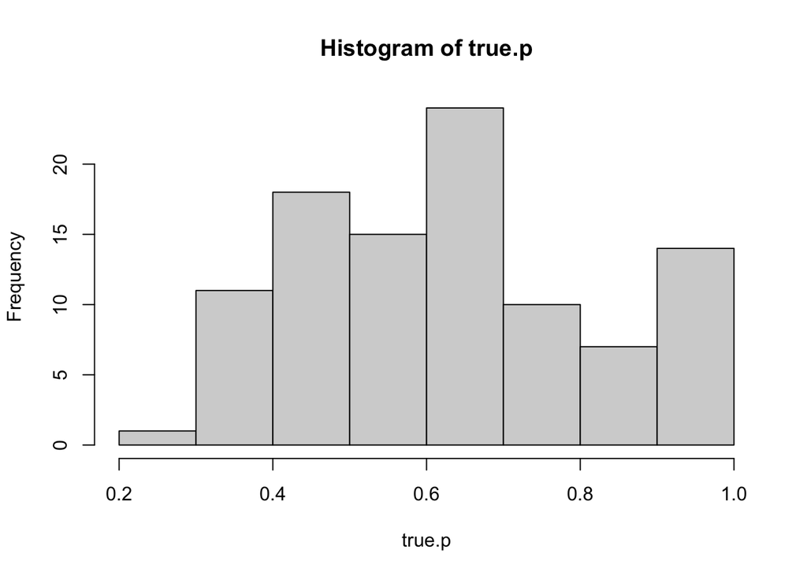

```r
rm(cure, trial.dat, true.beta, true.p, x, xpred)


#alpha = 0.49
x <- runif(n=2*n_arm, min = -1, max=1)
true.beta <- 0.3
true.p <- 0.49+true.beta*treat+0.2*x
hist(true.p)
```

```r
xpred <- x
TEfun <- function(x){
  return(true.beta)
}

cure <- rbinom(n=length(treat), size=1, prob = true.p)
trial.dat <- data.frame(cure, treat, x)


plots <- run.sim(true.beta=true.beta,
        trial.dat = trial.dat,
        filename="2x_cont_p=0.49+0.3x+0.2x",
        title=expression(paste(x[i*1], " binary, ", x[i*2], "~U[-1,1], ", p[i],"=0.49+0.3",x[i*1],"+0.2",x[i*2],".")),
        true.p = true.p,
        true.TE.fun=TEfun,
        xpred = xpred,
        beta_xlim = c(0,0.6),
        beta_ylim = c(0,20))
```

[output not shown]

[output cut: 1203 more lines]

```
## pred.effect[94]    660
## pred.effect[95]    660
## pred.effect[96]    660
## pred.effect[97]    660
## pred.effect[98]    660
## pred.effect[99]    660
## pred.effect[100]   660
## deviance          2000
##
## For each parameter, n.eff is a crude measure of effective sample size,
## and Rhat is the potential scale reduction factor (at convergence, Rhat=1).
##
## DIC info (using the rule, pD = var(deviance)/2)
## pD = 2.7 and DIC = 107.4
## DIC is an estimate of expected predictive error (lower deviance is better).
```

```r
beta.plot <- rbind(beta.plot, plots$beta.frame)
plots$kable_modstats
```

1. Proposed model
3. Logistic model + transform
2. Model by Warn et al.

MLE binomial GLM id-link

MLE binomial GLM logit-link

OLS estimate

Brier.mean

0.1750

0.1609

0.1709

NA

0.1610

0.1689

Brier.median

0.1745

0.1609

0.1709

NA

0.1610

0.1689

RMSE.p.mean

0.0218

0.0947

0.0348

NA

0.0948

0.0672

RMSE.p.median

0.0194

0.0994

0.0365

NA

0.0948

0.0672

MAE.p.mean

0.0207

0.0774

0.0293

NA

0.0776

0.0541

MAE.p.median

0.0186

0.0816

0.0311

NA

0.0776

0.0541

IC

110.6417

105.1064

107.4409

0.000

104.5296

NA

Rhat_Conv

1.0039

1.0010

1.0028

0.000

-1.0000

-1.0000

RunTimes

4.3488

2.6145

3.5943

0.001

0.0013

0.0007

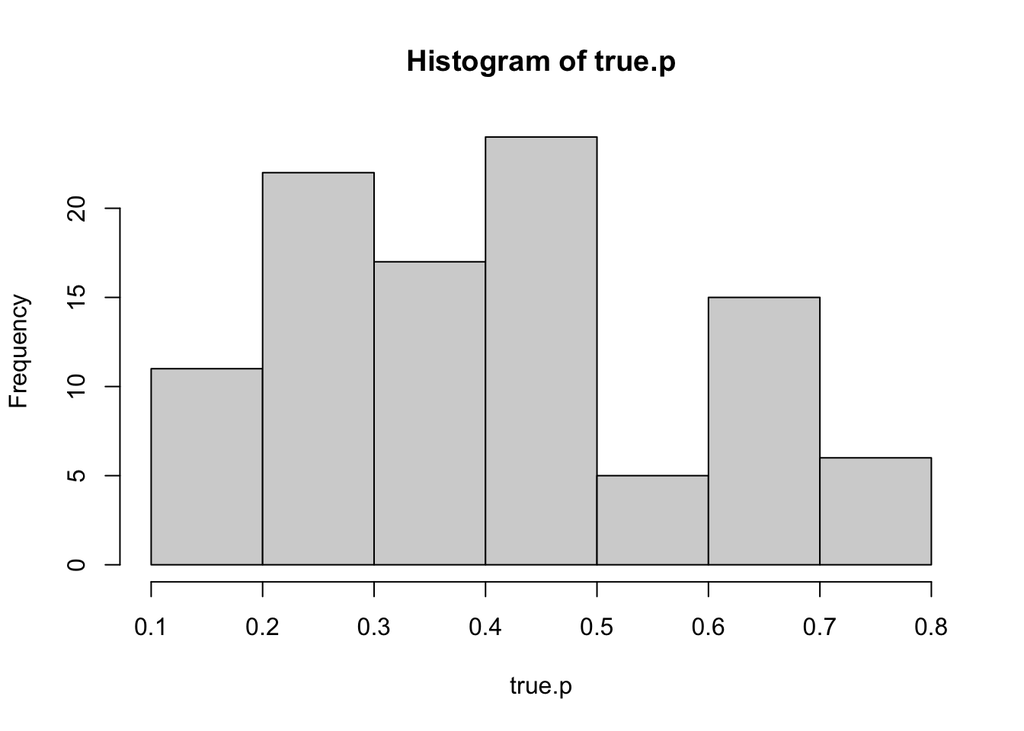

```r
rm(cure, trial.dat, true.beta, true.p, x, xpred)

#true logit link
# alpha=-1
x <- runif(n=2*n_arm, min = -1, max=1)

true.beta <- NA
true.p <- expit(-1+1*treat+x)
hist(true.p)
```

```r
xpred <- x
TEfun <- function(x){
  TE <- expit(-1+1+x)-expit(-1+0+x)
  return(TE)
}

cure <- rbinom(n=length(treat), size=1, prob = true.p)
trial.dat <- data.frame(cure, treat, x)

plots <- run.sim(true.beta=true.beta,
        trial.dat = trial.dat,
        filename="2x_cont_p=expit(-1+x+x)",
        title=expression(paste(x[i*1], " binary, ", x[i*2], "~U[-1,1], ", p[i],"=expit(-1+",x[i*1],"+",x[i*2],")")),
        true.p = true.p,
        true.TE.fun=TEfun,
        xpred = xpred,
        beta_xlim = c(0,0.6),
        beta_ylim = c(0,20))
```

[output not shown]

[output cut: 1203 more lines]

```
## pred.effect[94]    790
## pred.effect[95]    790
## pred.effect[96]    790
## pred.effect[97]    790
## pred.effect[98]    790
## pred.effect[99]    790
## pred.effect[100]   790
## deviance          2000
##
## For each parameter, n.eff is a crude measure of effective sample size,
## and Rhat is the potential scale reduction factor (at convergence, Rhat=1).
##
## DIC info (using the rule, pD = var(deviance)/2)
## pD = 2.8 and DIC = 119.1
## DIC is an estimate of expected predictive error (lower deviance is better).
```

```r
beta.plot <- rbind(beta.plot, plots$beta.frame)
plots$kable_modstats
```

1. Proposed model
3. Logistic model + transform
2. Model by Warn et al.

MLE binomial GLM id-link

MLE binomial GLM logit-link

OLS estimate

Brier.mean

0.1922

0.1860

0.1911

NA

0.1862

0.1895

Brier.median

0.1920

0.1861

0.1910

NA

0.1862

0.1895

RMSE.p.mean

0.0482

0.0730

0.0515

NA

0.0735

0.0728

RMSE.p.median

0.0496

0.0772

0.0528

NA

0.0735

0.0728

MAE.p.mean

0.0450

0.0623

0.0461

NA

0.0622

0.0584

MAE.p.median

0.0457

0.0662

0.0469

NA

0.0622

0.0584

IC

118.8977

118.2634

119.0930

0.000

117.7997

NA

Rhat_Conv

1.0029

1.0020

1.0024

0.000

-1.0000

-1.0000

RunTimes

5.1603

2.6880

3.6309

0.002

0.0022

0.0014

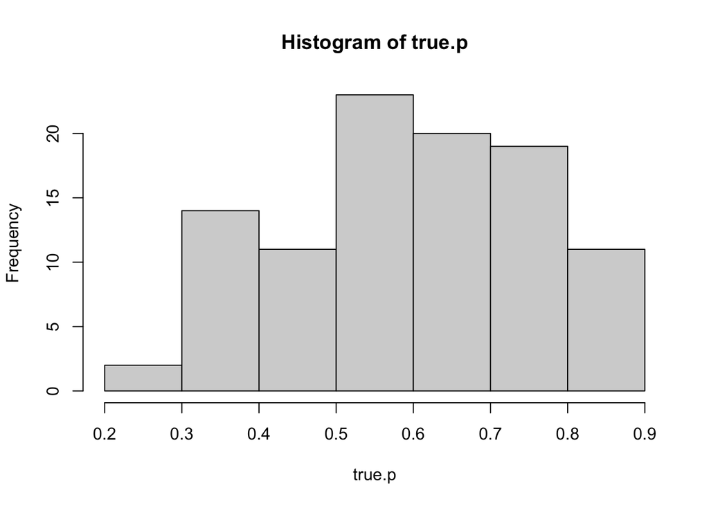

```r
rm(cure, trial.dat, true.beta, true.p, x, xpred)

# alpha=0
x <- runif(n=2*n_arm, min = -1, max=1)

true.beta <- NA
true.p <- expit(0+1*treat+x)
hist(true.p)
```

```r
xpred <- x
TEfun <- function(x){
  TE <- expit(0+1+x)-expit(0+0+x)
  return(TE)
}

cure <- rbinom(n=length(treat), size=1, prob = true.p)
trial.dat <- data.frame(cure, treat, x)

plots <- run.sim(true.beta=true.beta,
        trial.dat = trial.dat,
        filename="2x_cont_p=expit(0+x+x)",
        title=expression(paste(x[i*1], " binary, ", x[i*2], "~U[-1,1], ", p[i],"=expit(0+",x[i*1],"+",x[i*2],")")),
        true.p = true.p,
        true.TE.fun=TEfun,
        xpred = xpred,
        beta_xlim = c(0,0.6),
        beta_ylim = c(0,20))
```

[output not shown]

[output cut: 1203 more lines]

```
## pred.effect[94]   2000
## pred.effect[95]   2000
## pred.effect[96]   2000
## pred.effect[97]   2000
## pred.effect[98]   2000
## pred.effect[99]   2000
## pred.effect[100]  2000
## deviance          2000
##
## For each parameter, n.eff is a crude measure of effective sample size,
## and Rhat is the potential scale reduction factor (at convergence, Rhat=1).
##
## DIC info (using the rule, pD = var(deviance)/2)
## pD = 2.6 and DIC = 118.8
## DIC is an estimate of expected predictive error (lower deviance is better).
```

```r
beta.plot <- rbind(beta.plot, plots$beta.frame)
plots$kable_modstats
```

1. Proposed model
3. Logistic model + transform
2. Model by Warn et al.

MLE binomial GLM id-link

MLE binomial GLM logit-link

OLS estimate

Brier.mean

0.1949

0.1941

0.1943

0.1942

0.1939

0.1941

Brier.median

0.1946

0.1940

0.1943

0.1942

0.1939

0.1941

RMSE.p.mean

0.0938

0.0983

0.0891

0.0983

0.0974

0.0982

RMSE.p.median

0.0956

0.1022

0.0916

0.0983

0.0974

0.0982

MAE.p.mean

0.0799

0.0948

0.0842

0.0947

0.0943

0.0943

MAE.p.median

0.0832

0.0995

0.0873

0.0947

0.0943

0.0943

IC

119.8902

119.8089

118.8078

119.3051

120.0826

NA

Rhat_Conv

1.0012

1.0021

1.0006

-1.0000

-1.0000

-1.0000

RunTimes

5.1625

2.4630

3.0445

0.0023

0.0011

0.0007

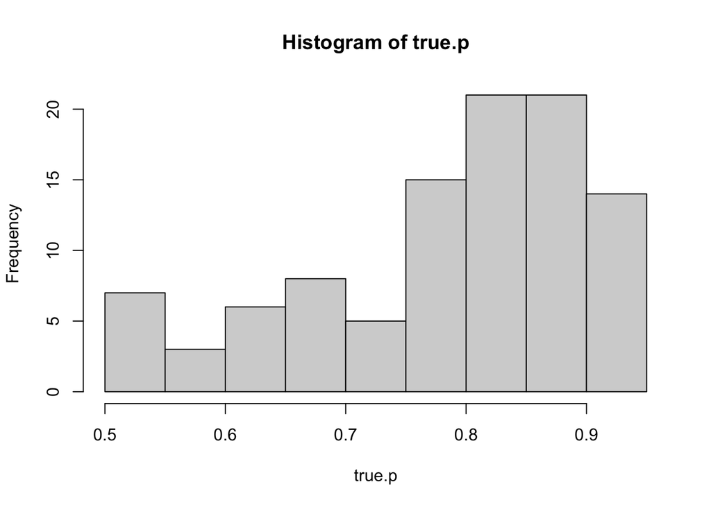

```r
rm(cure, trial.dat, true.beta, true.p, x, xpred)

# alpha=1
x <- runif(n=2*n_arm, min = -1, max=1)

true.beta <- NA
true.p <- expit(1+1*treat+x)
hist(true.p)
```

```r
xpred <- x
TEfun <- function(x){
  TE <- expit(1+1+x)-expit(1+0+x)
  return(TE)
}

cure <- rbinom(n=length(treat), size=1, prob = true.p)
trial.dat <- data.frame(cure, treat, x)

plots <- run.sim(true.beta=true.beta,
        trial.dat = trial.dat,
        filename="2x_cont_p=expit(1+x+x)",
        title=expression(paste(x[i*1], " binary, ", x[i*2], "~U[-1,1], ", p[i],"=expit(1+",x[i*1],"+",x[i*2],")")),
        true.p = true.p,
        true.TE.fun=TEfun,
        xpred = xpred,
        beta_xlim = c(0,0.6),
        beta_ylim = c(0,20))
```

[output not shown]

[output cut: 589 more lines]

```
## pred.effect[94]    0.050   0.067 -0.082  0.006  0.050  0.093  0.185 1.003  2000
## pred.effect[95]    0.050   0.067 -0.082  0.006  0.050  0.093  0.185 1.003  2000
## pred.effect[96]    0.050   0.067 -0.082  0.006  0.050  0.093  0.185 1.003  2000
## pred.effect[97]    0.050   0.067 -0.082  0.006  0.050  0.093  0.185 1.003  2000
## pred.effect[98]    0.050   0.067 -0.082  0.006  0.050  0.093  0.185 1.003  2000
## pred.effect[99]    0.050   0.067 -0.082  0.006  0.050  0.093  0.185 1.003  2000
## pred.effect[100]   0.050   0.067 -0.082  0.006  0.050  0.093  0.185 1.003  2000
## deviance          83.083   2.591 80.135 81.235 82.424 84.255 89.322 1.005   320
##
## For each parameter, n.eff is a crude measure of effective sample size,
## and Rhat is the potential scale reduction factor (at convergence, Rhat=1).
##
## DIC info (using the rule, pD = var(deviance)/2)
## pD = 3.3 and DIC = 86.4
## DIC is an estimate of expected predictive error (lower deviance is better).
```

```r
beta.plot <- rbind(beta.plot, plots$beta.frame)
plots$kable_modstats
```

1. Proposed model
3. Logistic model + transform
2. Model by Warn et al.

MLE binomial GLM id-link

MLE binomial GLM logit-link

OLS estimate

Brier.mean

0.1265

0.1235

0.1259

0.1255

0.1236

0.1254

Brier.median

0.1263

0.1235

0.1257

0.1255

0.1236

0.1254

RMSE.p.mean

0.0758

0.0793

0.0723

0.0835

0.0770

0.0793

RMSE.p.median

0.0780

0.0845

0.0768

0.0835

0.0770

0.0793

MAE.p.mean

0.0592

0.0628

0.0638

0.0705

0.0611

0.0643

MAE.p.median

0.0598

0.0671

0.0678

0.0705

0.0611

0.0643

IC

87.3486

86.8929

86.4323

86.0030

86.8564

NA

Rhat_Conv

1.0022

1.0005

1.0028

-1.0000

-1.0000

-1.0000

RunTimes

4.4302

2.3677

3.4764

0.0028

0.0013

0.0007

[figure not shown]

```r
rm(cure, trial.dat, true.beta, true.p, x, xpred)

# Plots
beta.plot$Scenario <- factor(beta.plot$Scenario,
                   levels=c("2x_cont_p=0.3+0.3x+0.2x",
                            "2x_cont_p=0.4+0.3x+0.2x",
                            "2x_cont_p=0.49+0.3x+0.2x",
                            "2x_cont_p=expit(-1+x+x)",
                            "2x_cont_p=expit(0+x+x)",
                            "2x_cont_p=expit(1+x+x)"),
                   labels=c(expression(paste("A. ", x[i*1], " binary, ", x[i*2], "~U[-1,1], ", p[i],"=0.3+0.3",x[i*1],"+0.2",x[i*2],".")),
                            expression(paste("B. ", x[i*1], " binary, ", x[i*2], "~U[-1,1], ", p[i],"=0.4+0.3",x[i*1],"+0.2",x[i*2],".")),
                            expression(paste("C. ", x[i*1], " binary, ", x[i*2], "~U[-1,1], ", p[i],"=0.49+0.3",x[i*1],"+0.2",x[i*2],".")),
                            expression(paste("D. ", x[i*1], " binary, ", x[i*2], "~U[-1,1], ", p[i],"=expit(-1+",x[i*1],"+",x[i*2],")")),
                            expression(paste("E. ", x[i*1], " binary, ", x[i*2], "~U[-1,1], ", p[i],"=expit(0+",x[i*1],"+",x[i*2],")")),
                            expression(paste("F. ", x[i*1], " binary, ", x[i*2], "~U[-1,1], ", p[i],"=expit(1+",x[i*1],"+",x[i*2],")"))
                            ))

 plot1<- ggplot(beta.plot, aes(x=xtilde, fill = model))+
      geom_ribbon(aes(ymin = TE_low, ymax = TE_upp), alpha=0.3)+
      geom_line(aes(y = TE_pred, color=model))+
      xlab(expression(x[i*2]))+
      ylab(expression(paste("Treatment effect (RD)")))+
      theme_bw()+
      #xlim(c(-1.1,1.1))+
      ylim(c(-0.2,0.8))+
      facet_wrap(~Scenario, ncol = 2, dir = "v", labeller = label_parsed)


print(plot1)
```

```r
ggsave(plot = plot1, filename="2x_cont.pdf", height=6, width = 8.4)
```